# Biostat 203B Homework 4

Due Mar 18 @ 11:59PM

Zixuan Cai

Load database libraries and the tidyverse frontend:

```r
suppressPackageStartupMessages(library(tidyverse))
suppressPackageStartupMessages(library(lubridate))
suppressPackageStartupMessages(library(miceRanger))
```

## Q1. Missing data

Through the Shiny app developed in HW3, we observe abundant missing values in the MIMIC-IV ICU cohort we created. In this question, we use multiple imputation to obtain a data set without missing values.

0. Read following tutorials on the R package miceRanger for imputation: https://github.com/farrellday/miceRanger, https://cran.r-project.org/web/packages/miceRanger/vignettes/miceAlgorithm.html.

   A more thorough book treatment of the practical imputation strategies is the book [*Flexible Imputation of Missing Data*](https://stefvanbuuren.name/fimd/) by Stef van Buuren.
1. Explain the jargon MCAR, MAR, and MNAR.  
   **Solution:**  
   `MCAR` stands for “missing completely at random”, which means that the probability of being missing is the same for all cases.  
   `MAR` stands for “missing at random”, a much broader class than `MCAR`, which means that the probability of being missing is the same only within groups defined by the observed data, then the data are missing at random. It is also more general and more realistic than `MCAR`, and thus modern missing data methods generally start from the `MAR` assumption.  
   `NMAR` is the case when neither `MAR` nor`MAR` holds and it stands for “not missing at random”——the probability of being missing varies for reasons that are unknown to us.
2. Explain in a couple of sentences how the Multiple Imputation by Chained Equations (MICE) work.  
   **Solution:**  
   `MICE` is a robust, informative method of dealing with missing values in datasets. The missing values in each specified variable in the dataset are imputed using the non-missing values of the other variables in the same dataset. The process of determining the values to be imputed involves a procedure called predictive mean matching (PMM). This process continues until all specified variables have been imputed and that an optimal convergence has been met (higher R-squared value).
3. Perform a data quality check of the ICU stays data. Discard variables with substantial missingness, say >5000 `NA`s. Replace apparent data entry errors by `NA`s.  
   **Solution:**  
   Importing data table `icu_cohort`:

```r
icu_cohort <- read_rds("icu_cohort.rds")
```

Count the number of `NA`’s:

```r
colSums(is.na(icu_cohort))
```

```
##           subject_id               intime              hadm_id
##                    0                    0                    0
##              stay_id       first_careunit        last_careunit
##                    0                    0                    0
##              outtime                  los            admittime
##                    0                    0                    0
##            dischtime            deathtime       admission_type
##                    0                47642                    0
##   admission_location   discharge_location            insurance
##                    0                  495                    0
##             language       marital_status            ethnicity
##                    0                 4631                    0
##            edregtime            edouttime hospital_expire_flag
##                19618                19618                    0
##               gender           anchor_age          anchor_year
##                    0                    0                    0
##    anchor_year_group                  dod              age_adm
##                    0                45232                    0
##              glucose           hematocrit                  wbc
##                12521                 5769                 7293
##          bicarbonate            potassium            magnesium
##                11355                11117                13861
##              calcium               sodium           creatinine
##                14380                11180                11161
##             chloride                 NBPm                 NBPs
##                10898                38112                38171
##                   HR                   RR               Temp_F
##                14373                17441                41503
##      thirty_day_mort
##                45232
```

```r
sum(is.na(icu_cohort))
```

```
## [1] 441603
```

```r
icu_cohort <-
  icu_cohort %>%
  select(-deathtime, -dod, -glucose, -hematocrit, -wbc, -bicarbonate,
         -potassium, -magnesium, -calcium, -sodium, -creatinine, -chloride,
         -NBPm, -NBPs, -HR, -RR, -Temp_F, -edregtime, -edouttime)
```

Next, find the number of outliers in variable `los` and decide whether to discard it:

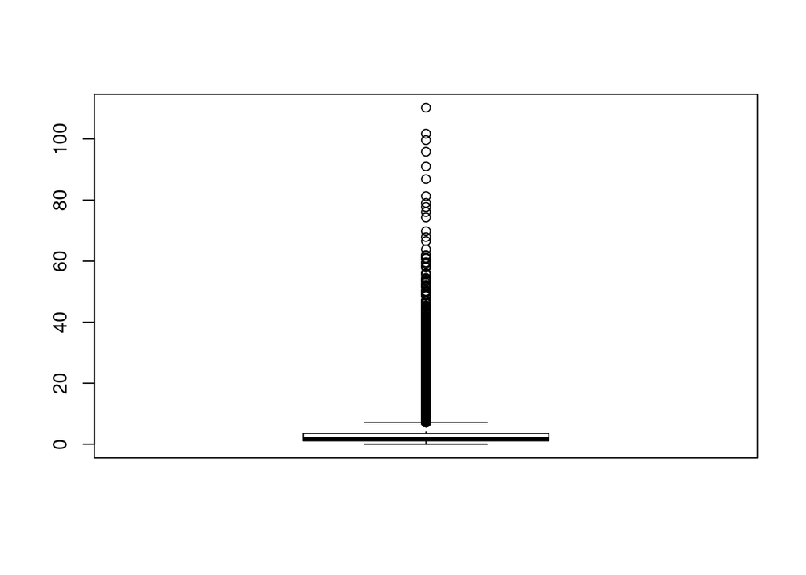

```r
boxplot(icu_cohort$los)
```

```r
outliers1 <- boxplot(icu_cohort$los, plot = FALSE)$out
icu_cohort$is_outlier <-
  ifelse(icu_cohort$los %in% boxplot.stats(icu_cohort$los)$out, 1, 0)

length(which(icu_cohort$is_outlier == 1))
```

```
## [1] 5280
```

We have 5280 outliers in this variable (`los`) and it should be discarded:

```r
icu_cohort <-
  icu_cohort %>%
  select(-los, -is_outlier)
```

Next, find the number of outliers in variable `anchor_age` and decide whether to discard it:

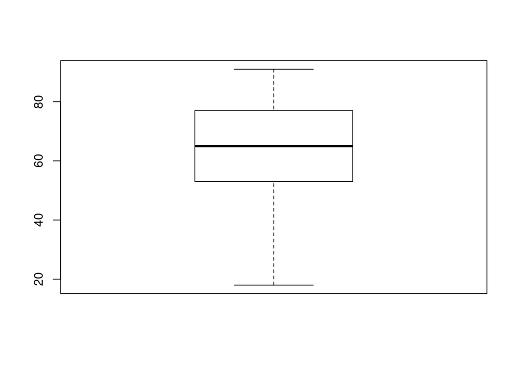

```r
boxplot(icu_cohort$anchor_age)
```

```r
outliers1 <- boxplot(icu_cohort$anchor_age, plot = FALSE)$out
icu_cohort$is_outlier <-
  ifelse(icu_cohort$anchor_age %in% boxplot.stats(icu_cohort$anchor_age)$out, 1, 0)

length(which(icu_cohort$is_outlier == 1))
```

```
## [1] 0
```

We have no outliers in this variable (`anchor_age`) and it should not be discarded:

```r
icu_cohort <-
  icu_cohort %>%
  select(-is_outlier)
```

Next, find the number of outliers in variable `anchor_year` and decide whether to discard it:

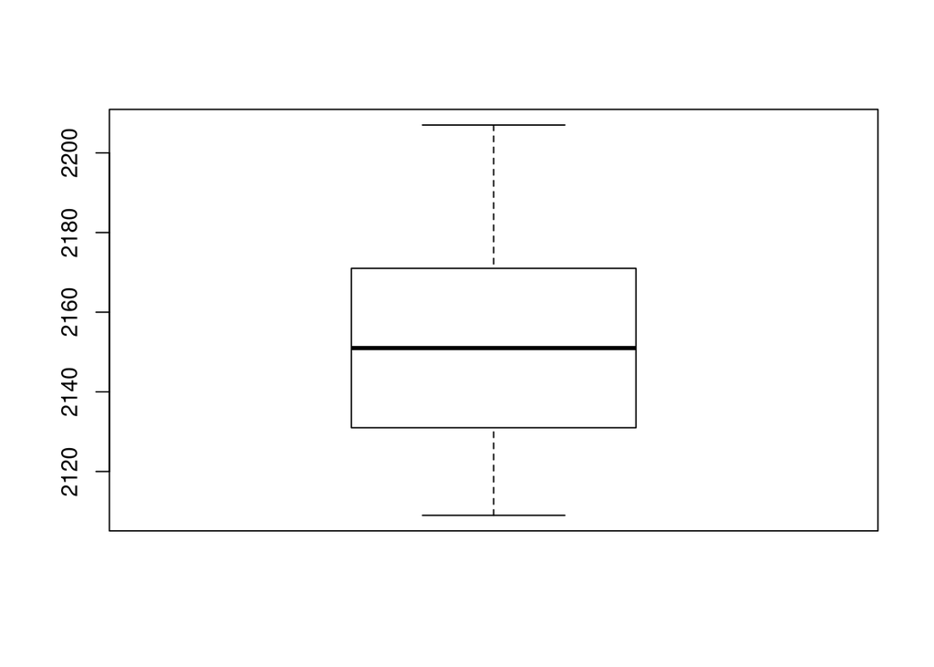

```r
boxplot(icu_cohort$anchor_year)
```

```r
outliers1 <- boxplot(icu_cohort$anchor_year, plot = FALSE)$out
icu_cohort$is_outlier <-
  ifelse(icu_cohort$anchor_year %in% boxplot.stats(icu_cohort$anchor_year)$out, 1, 0)

length(which(icu_cohort$is_outlier == 1))
```

```
## [1] 0
```

We have no outliers in this variable (`anchor_year`) and it should not be discarded:

```r
icu_cohort <-
  icu_cohort %>%
  select(-is_outlier)
```

Next, find the number of outliers in variable `age_adm` and decide whether to discard it:

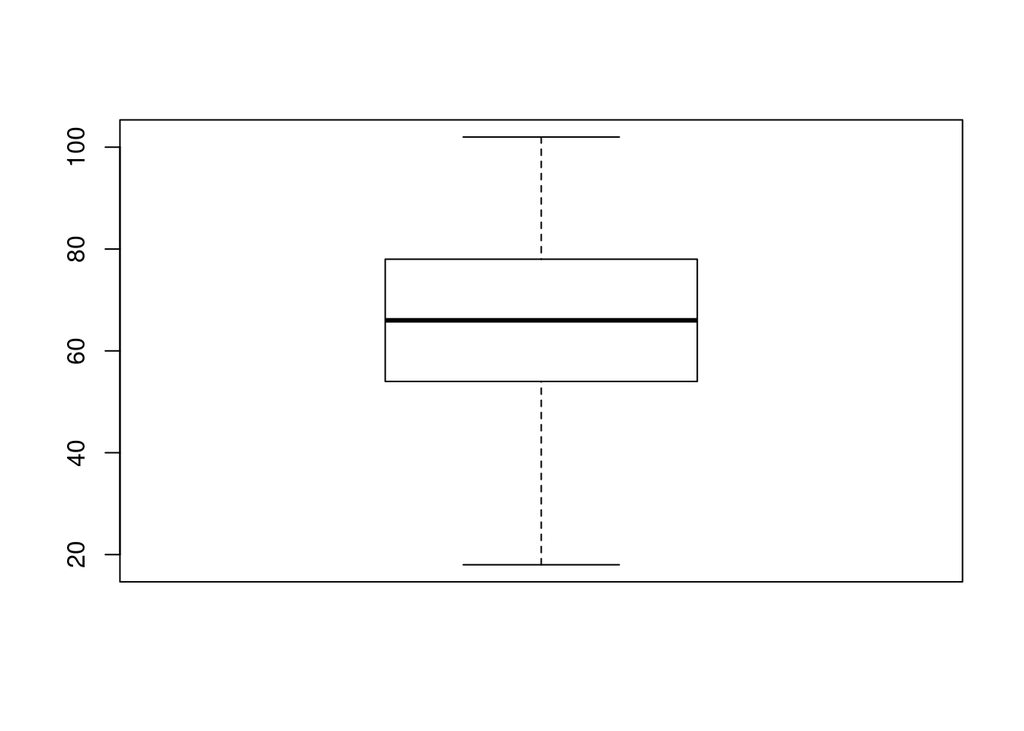

```r
boxplot(icu_cohort$age_adm)
```

```r
outliers1 <- boxplot(icu_cohort$age_adm, plot = FALSE)$out
icu_cohort$is_outlier <-
  ifelse(icu_cohort$age_adm %in% boxplot.stats(icu_cohort$age_adm)$out, 1, 0)

length(which(icu_cohort$is_outlier == 1))
```

```
## [1] 0
```

We have no outliers in this variable (`age_adm`) and it should not be discarded:

```r
icu_cohort <-
  icu_cohort %>%
  select(-is_outlier)
```

```r
head(icu_cohort)
```

```
##   subject_id              intime  hadm_id  stay_id first_careunit
## 1   12776735 2200-07-12 00:33:00 20817525 34547665 Neuro Stepdown
## 2   16256226 2150-12-20 16:09:08 20013290 39289362 Neuro Stepdown
## 3   12974563 2138-11-13 23:30:01 29618057 32563675 Neuro Stepdown
## 4   14609218 2174-06-28 21:13:00 20606189 34947848 Neuro Stepdown
## 5   12687112 2162-05-31 18:08:45 26132667 37445058 Neuro Stepdown
## 6   18190935 2115-11-12 23:23:32 21137829 34338402 Neuro Stepdown
##    last_careunit             outtime           admittime           dischtime
## 1 Neuro Stepdown 2200-07-13 16:44:40 2200-07-11 22:46:00 2200-07-19 12:00:00
## 2 Neuro Stepdown 2150-12-21 14:58:40 2150-12-20 03:00:00 2150-12-21 14:50:00
## 3 Neuro Stepdown 2138-11-15 16:25:19 2138-11-13 01:07:00 2138-11-15 15:53:00
## 4 Neuro Stepdown 2174-07-05 17:01:32 2174-06-28 20:40:00 2174-07-05 16:45:00
## 5 Neuro Stepdown 2162-06-04 10:16:13 2162-05-31 15:36:00 2162-06-04 10:16:00
## 6 Neuro Stepdown 2115-11-15 18:06:26 2115-11-02 18:38:00 2115-11-26 14:30:00
##                admission_type     admission_location
```

[output cut: 34 more lines]

```r
icu_cohort1 <-
  icu_cohort %>%
  mutate(intime_n = as.numeric(intime),
         outtime_n = as.numeric(outtime),
         admittime_n = as.numeric(admittime),
         dischtime_n = as.numeric(dischtime)
         ) %>%
  select(-intime, -outtime, -admittime, -dischtime)

head(icu_cohort1)
```

```
##   subject_id  hadm_id  stay_id first_careunit  last_careunit
## 1   12776735 20817525 34547665 Neuro Stepdown Neuro Stepdown
## 2   16256226 20013290 39289362 Neuro Stepdown Neuro Stepdown
## 3   12974563 29618057 32563675 Neuro Stepdown Neuro Stepdown
## 4   14609218 20606189 34947848 Neuro Stepdown Neuro Stepdown
## 5   12687112 26132667 37445058 Neuro Stepdown Neuro Stepdown
## 6   18190935 21137829 34338402 Neuro Stepdown Neuro Stepdown
##                admission_type     admission_location
## 1           OBSERVATION ADMIT         EMERGENCY ROOM
## 2 SURGICAL SAME DAY ADMISSION     PHYSICIAN REFERRAL
## 3           OBSERVATION ADMIT         EMERGENCY ROOM
## 4           OBSERVATION ADMIT         EMERGENCY ROOM
## 5           OBSERVATION ADMIT     PHYSICIAN REFERRAL
## 6           OBSERVATION ADMIT TRANSFER FROM HOSPITAL
##             discharge_location insurance language marital_status
```

[output cut: 27 more lines]

4. Impute missing values by `miceRanger` (request $m=3$ data sets). This step is computational intensive. Make sure to save the imputation results as a file. Hint: Setting `max.depth=10` in the `miceRanger` function may cut some computing time. **Solution:**  
   Perform mice, return 3 datasets:

```r
set.seed(1)

icu_imp <- miceRanger(icu_cohort1,
                          m = 3,
                          valueSelector = "meanMatch",
                          verbose=FALSE,
                          max.depth=10)
```

```r
saveRDS(icu_imp, file = "icu_cohort.rds")
```

**For reproducibility:** Read the imputed data from the RDS file created from the above code chunk to save run time:

```r
icu_imp <- readRDS("icu_cohort.rds")
```

5. Make imputation diagnostic plots and explain what they mean.  
   Return the imputed data:

```r
dataList <- completeData(icu_imp)
head(dataList[[1]],10)
```

```
##     subject_id  hadm_id  stay_id first_careunit  last_careunit
##  1:   12776735 20817525 34547665 Neuro Stepdown Neuro Stepdown
##  2:   16256226 20013290 39289362 Neuro Stepdown Neuro Stepdown
##  3:   12974563 29618057 32563675 Neuro Stepdown Neuro Stepdown
##  4:   14609218 20606189 34947848 Neuro Stepdown Neuro Stepdown
##  5:   12687112 26132667 37445058 Neuro Stepdown Neuro Stepdown
##  6:   18190935 21137829 34338402 Neuro Stepdown Neuro Stepdown
##  7:   10404210 22880512 30254828 Neuro Stepdown Neuro Stepdown
##  8:   12552973 21320643 30261549 Neuro Stepdown Neuro Stepdown
##  9:   14303051 26559537 30401486 Neuro Stepdown Neuro Stepdown
## 10:   12347959 22779073 30503984 Neuro Stepdown Neuro Stepdown
##                  admission_type     admission_location
##  1:           OBSERVATION ADMIT         EMERGENCY ROOM
##  2: SURGICAL SAME DAY ADMISSION     PHYSICIAN REFERRAL
##  3:           OBSERVATION ADMIT         EMERGENCY ROOM
```

[output cut: 51 more lines]

```r
head(dataList[[2]],10)
```

```
##     subject_id  hadm_id  stay_id first_careunit  last_careunit
##  1:   12776735 20817525 34547665 Neuro Stepdown Neuro Stepdown
##  2:   16256226 20013290 39289362 Neuro Stepdown Neuro Stepdown
##  3:   12974563 29618057 32563675 Neuro Stepdown Neuro Stepdown
##  4:   14609218 20606189 34947848 Neuro Stepdown Neuro Stepdown
##  5:   12687112 26132667 37445058 Neuro Stepdown Neuro Stepdown
##  6:   18190935 21137829 34338402 Neuro Stepdown Neuro Stepdown
##  7:   10404210 22880512 30254828 Neuro Stepdown Neuro Stepdown
##  8:   12552973 21320643 30261549 Neuro Stepdown Neuro Stepdown
##  9:   14303051 26559537 30401486 Neuro Stepdown Neuro Stepdown
## 10:   12347959 22779073 30503984 Neuro Stepdown Neuro Stepdown
##                  admission_type     admission_location
##  1:           OBSERVATION ADMIT         EMERGENCY ROOM
##  2: SURGICAL SAME DAY ADMISSION     PHYSICIAN REFERRAL
##  3:           OBSERVATION ADMIT         EMERGENCY ROOM
```

[output cut: 51 more lines]

```r
head(dataList[[3]],10)
```

```
##     subject_id  hadm_id  stay_id first_careunit  last_careunit
##  1:   12776735 20817525 34547665 Neuro Stepdown Neuro Stepdown
##  2:   16256226 20013290 39289362 Neuro Stepdown Neuro Stepdown
##  3:   12974563 29618057 32563675 Neuro Stepdown Neuro Stepdown
##  4:   14609218 20606189 34947848 Neuro Stepdown Neuro Stepdown
##  5:   12687112 26132667 37445058 Neuro Stepdown Neuro Stepdown
##  6:   18190935 21137829 34338402 Neuro Stepdown Neuro Stepdown
##  7:   10404210 22880512 30254828 Neuro Stepdown Neuro Stepdown
##  8:   12552973 21320643 30261549 Neuro Stepdown Neuro Stepdown
##  9:   14303051 26559537 30401486 Neuro Stepdown Neuro Stepdown
## 10:   12347959 22779073 30503984 Neuro Stepdown Neuro Stepdown
##                  admission_type     admission_location
##  1:           OBSERVATION ADMIT         EMERGENCY ROOM
##  2: SURGICAL SAME DAY ADMISSION     PHYSICIAN REFERRAL
##  3:           OBSERVATION ADMIT         EMERGENCY ROOM
```

[output cut: 51 more lines]

Diagnostic plots:

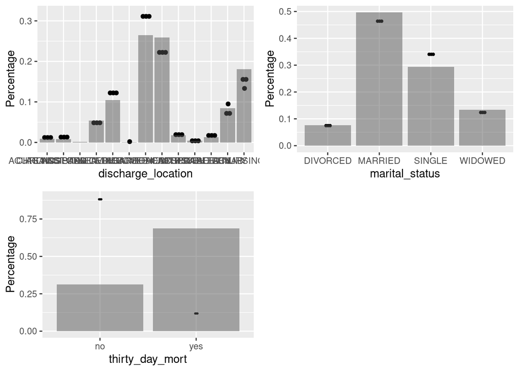

```r
plotDistributions(miceObj = icu_imp)
```

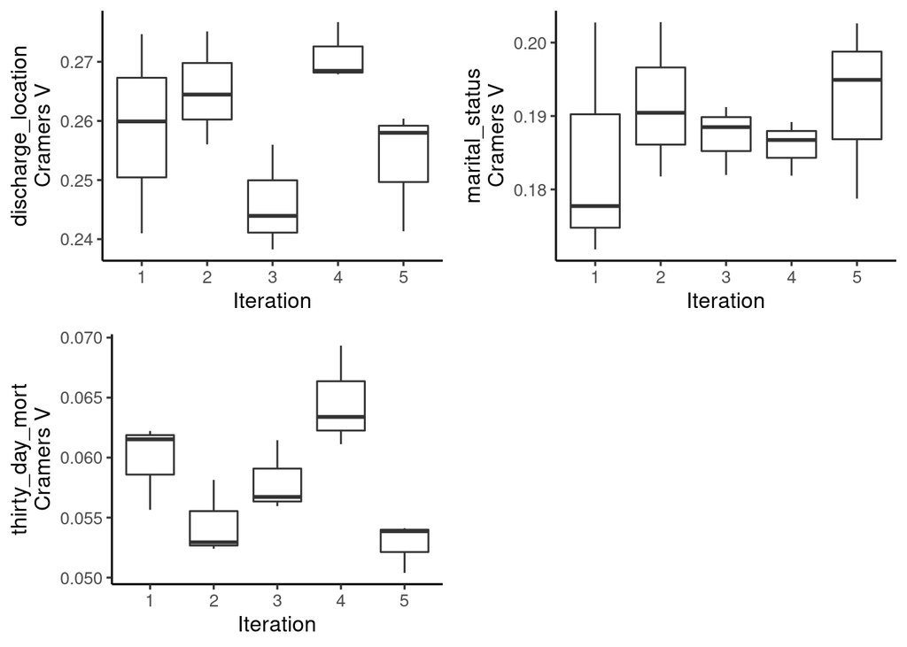

```r
plotCorrelations(miceObj = icu_imp)
```

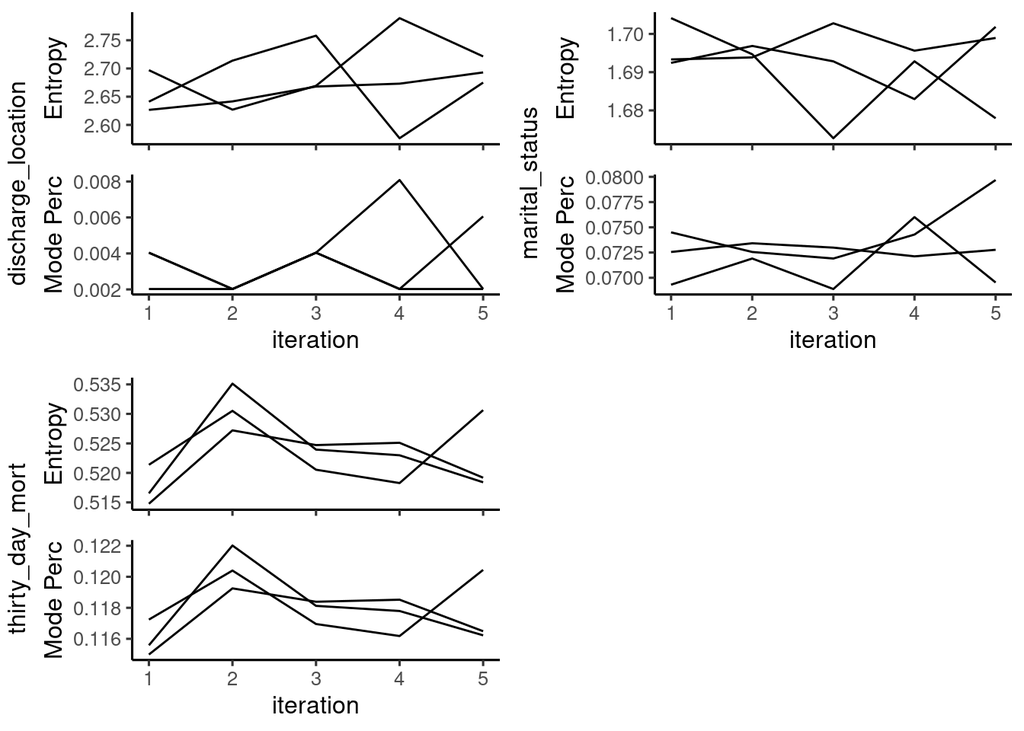

```r
plotVarConvergence(miceObj = icu_imp)
```

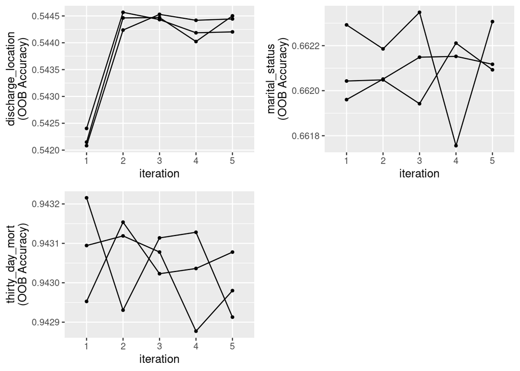

```r
plotModelError(miceObj = icu_imp)
```

6. Choose one of the imputed data sets to be used in Q2. This is **not** a good idea to use just one imputed data set or to average multiple imputed data sets. Explain in a couple of sentences what the correct Multiple Imputation strategy is.  
   **Solution:**  
   The correct strategy is to select a imputed dataset with the highest correlations among variables of interest. When convergence has been met, we can terminate the iterations.

```r
data1 <- dataList[[1]]
head(data1)
```

```
##    subject_id  hadm_id  stay_id first_careunit  last_careunit
## 1:   12776735 20817525 34547665 Neuro Stepdown Neuro Stepdown
## 2:   16256226 20013290 39289362 Neuro Stepdown Neuro Stepdown
## 3:   12974563 29618057 32563675 Neuro Stepdown Neuro Stepdown
## 4:   14609218 20606189 34947848 Neuro Stepdown Neuro Stepdown
## 5:   12687112 26132667 37445058 Neuro Stepdown Neuro Stepdown
## 6:   18190935 21137829 34338402 Neuro Stepdown Neuro Stepdown
##                 admission_type     admission_location
## 1:           OBSERVATION ADMIT         EMERGENCY ROOM
## 2: SURGICAL SAME DAY ADMISSION     PHYSICIAN REFERRAL
## 3:           OBSERVATION ADMIT         EMERGENCY ROOM
## 4:           OBSERVATION ADMIT         EMERGENCY ROOM
## 5:           OBSERVATION ADMIT     PHYSICIAN REFERRAL
## 6:           OBSERVATION ADMIT TRANSFER FROM HOSPITAL
##              discharge_location insurance language marital_status
```

[output cut: 27 more lines]

## Q2. Predicting 30-day mortality

Develop at least two analytic approaches for predicting the 30-day mortality of patients admitted to ICU using demographic information (gender, age, marital status, ethnicity), first lab measurements during ICU stay, and first vital measurements during ICU stay. For example, you can use (1) logistic regression (`glm()` function in base R or keras), (2) logistic regression with lasso penalty (glmnet or keras package), (3) random forest (randomForest package), or (4) neural network (keras package).

**Method 1: logistic regression with lasso penalty**  
1. Partition data into 80% training set and 20% test set. Stratify partitioning according the 30-day mortality status.

Preparing the dataset with variables of interest:

```r
library(dplyr)

train1 <-
  data1 %>%
  select(thirty_day_mort, gender, age_adm, marital_status, ethnicity)
```

```r
sum(is.na(train1))
head(train1)
```

[output not shown]

```r
# set training and test data set
train1 <- na.omit(train1)

smp_size <- floor(0.8 * nrow(train1))
set.seed(123)
train_ind <- sample(seq_len(nrow(train1)), size = smp_size)
train1$thirty_day_mort = as.factor(train1$thirty_day_mort)
train <- train1[train_ind, ]
test <- train1[-train_ind, ]
```

2. Train the models using the training set.

Install the packages if needed for reproducibility:

```r
install.packages("plotmo")
install.packages("caret")
install.packages("glmnet")
```

Using `glmnet` and `plotmo`:

```r
library(glmnet)
library(plotmo)
library(caret)

# transform the dataset into matrix form
x <- model.matrix(thirty_day_mort~., train)[,-1]
y <- ifelse(train$thirty_day_mort == "yes", 1, 0)

# build a model, set family as multinomial for multinomial logistic regression
lasso.mod = glmnet(x,
                   y, # thirty_day_mort, the outcome of interest
                   alpha = 1,
                   family = "binomial")
plot_glmnet(lasso.mod, label = 5, nresponse = 2)
```

[output not shown]

```r
library(glmnet)
library(dplyr)

# Find the best lambda using cross-validation
set.seed(123)
cv.lasso <- cv.glmnet(x, y, alpha = 1, family = "binomial")


# Fit the final model on the training data
model <- glmnet(x, y, alpha = 1, family = "binomial",
                lambda = cv.lasso$lambda.min)


# Display regression coefficients
coef(model)


# Make predictions on the test data
x.test <- model.matrix(thirty_day_mort ~., test)[,-1]
probabilities <- model %>%
  predict(newx = x.test)
predicted.classes <- ifelse(probabilities > 0.5, "yes", "no")


# Model accuracy
observed.classes <- test$thirty_day_mort
mean(predicted.classes == observed.classes)
```

[output not shown]

3. Compare model prediction performance on the test set.  
   **Accuracy:** 0.7955786

**Method 2: glm**  
Training:

```r
set.seed(1234)

create_train_test <- function(data, size = 0.8, train = TRUE) {
    n_row = nrow(data)
    total_row = size * n_row
    train_sample <- 1: total_row
    if (train == TRUE) {
        return (data[train_sample, ])
    } else {
        return (data[-train_sample, ])
    }
}
data_train <- create_train_test(train1, 0.8, train = TRUE)
data_test <- create_train_test(train1, 0.8, train = FALSE)
dim(data_train)
dim(data_test)

# training the train set
formula <- thirty_day_mort~.
logit <- glm(formula, data = data_train, family = 'binomial')
summary(logit)
```

[output not shown]

Testing accuracy:

```r
predict <- predict(logit, data_test, type = 'response')
# confusion matrix
table_mat <- table(data_test$thirty_day_mort, predict > 0.5)
table_mat


accuracy_Test <- sum(diag(table_mat)) / sum(table_mat)
accuracy_Test
```

[output not shown]

This gives an **accuracy** of 0.7826905.